# Player Valuation

### Introduction

Perhaps not surprisingly, I am huge fan of the [sabermetric revolution](https://en.wikipedia.org/wiki/Sabermetrics) within baseball (shocking, I know). And, after figuring out the weekly totals needed to ensure a playoff spot, I decided to see if I could devise a method for evaluating a player’s performance.

### Methods

In order to determine a given player’s value, we need to calculate the raw change in win probability for each category based on the weekly totals of a player. That is, if you were to add a player’s totals for a week to an average team, how would the odds of winning each category change.

```r
## getting raw change in win probability (i.e. Wins)

totals_batters %>%
  mutate(prob_50   = -coef_Int/coef_Value,
         new_total = case_when(Category == "AVG" ~ (prob_50*avg_AB + H)/(avg_AB + AB),
                               TRUE ~ prob_50+Total),
         new_prob  = 1/(1+exp(-(coef_Value*new_total + coef_Int))),
         Wins      = new_prob - 0.5
         ) -> totals_batters

totals_pitchers %>%
  mutate(prob_50   = -coef_Int/coef_Value,
         new_total = case_when(Category == "ERA"  ~ (prob_50/9*avg_IP + ER)/(avg_IP + IP)*9,
                               Category == "WHIP" ~ (prob_50*avg_IP + BR)/(avg_IP + IP),
                               TRUE ~ prob_50+Total),
         new_prob  = 1/(1+exp(-(coef_Value*new_total + coef_Int))),
         Wins      = new_prob - 0.5
         ) -> totals_pitchers
```

After calculating players’ raw performance, we need to compare it to some baseline in order to make it relative. Borrowing from the concept of [WAR](https://en.wikipedia.org/wiki/Wins_Above_Replacement), I decided to make my player valuation relative to replacement level.

In a standard ten team league, there are 250 rosters spots. Assuming that team owners are smart, these spots should be occupied by the best players. So our replacement level players should be pulled from the remaining pool of players and represent the best options available

In the code chunk below, we calculate the average number of Wins earned by each player in a week. Then, we rank the player by this average and select the fifty best players (25 pitchers and 25 batters) outside of the top 250. These are our replacement level players.

Our replacement levels players averaged just 0.293 Wins per week and include players such as Neil Walker, Lance Lynn, Kyle Schwarber, and Hunter Pence. That feels about right.

```r
## Getting average weekly wins per player

player_value %>%
  filter(Games > 0) %>%
  group_by(Player_ID,
           Player,
           Role,
           Week_ID) %>%
  summarise(Wins = sum(Wins)) %>%
  group_by(Player_ID,
           Player,
           Role) %>%
  summarise(avg_Wins = mean(Wins)) %>%
  ungroup() -> temp_replacements

## Getting list of replacement level players (top 25 P/B outside of the top 250 players)

temp_replacements %>%
  arrange(desc(avg_Wins)) %>%
  filter(row_number() > 250) %>%
  group_by(Role) %>%
  top_n(n  = 25,
        wt = avg_Wins) -> temp_replacements
```

After identifying our replacement level players, I grouped them by role and calculated the average Wins for each category. Then, I joined the these totals to the `player_value` data frame and subtracted them from the Win values of each player, giving us Wins Above Replacement (WAR).

```r
## Getting average weekly Wins for each category of replacement level players

player_value %>%
  filter(Player_ID %in% temp_replacements$Player_ID,
         Games > 0) %>%
  group_by(Match_Type,
           Role,
           Category) %>%
  summarise(r_Wins = mean(Wins)) -> temp_replacements

## Substracting replacement level performance from raw Wins

player_value %>%
  left_join(y  = temp_replacements,
            by = c("Match_Type", "Role", "Category")) %>%
  mutate(WAR = ifelse(Games == 0, 0, Wins - r_Wins)) %>%
  select(-r_Wins) -> player_value
```

### Results

In the table below, you can see the top 250 players in terms of WAR on the season. Paul Goldschmidt’s line of 166 runs, 120 RBIs, 36 home runs, 18 stolen bases, and 0.297 batting average tops the chart and was worth — according to my methodogy — roughly 9.5 wins above replacement.

| Player | Role | total_WAR | R | RBI | HR | SB | AVG | K | W | SV | ERA | WHIP |
| --- | --- | --- | --- | --- | --- | --- | --- | --- | --- | --- | --- | --- |
| Goldschmidt,Paul | B | 9.554 | 2.260 | 2.069 | 1.779 | 2.113 | 1.333 | 0.000 | 0.000 | 0.000 | 0.000 | 0.000 |
| Blackmon,Charlie | B | 9.204 | 2.790 | 1.147 | 1.662 | 1.488 | 2.117 | 0.000 | 0.000 | 0.000 | 0.000 | 0.000 |
| Altuve,Jose | B | 9.088 | 1.856 | 0.705 | 0.613 | 3.642 | 2.272 | 0.000 | 0.000 | 0.000 | 0.000 | 0.000 |
| Stanton,Giancarlo | B | 8.111 | 2.320 | 2.050 | 3.148 | -0.114 | 0.707 | 0.000 | 0.000 | 0.000 | 0.000 | 0.000 |
| Trout,Mike | B | 7.377 | 1.698 | 0.785 | 1.487 | 2.197 | 1.210 | 0.000 | 0.000 | 0.000 | 0.000 | 0.000 |
| Votto,Joey | B | 6.721 | 1.765 | 1.454 | 1.853 | 0.369 | 1.280 | 0.000 | 0.000 | 0.000 | 0.000 | 0.000 |
| Judge,Aaron | B | 6.702 | 2.143 | 1.218 | 2.216 | 0.660 | 0.465 | 0.000 | 0.000 | 0.000 | 0.000 | 0.000 |
| Andrus,Elvis | B | 6.570 | 1.688 | 0.818 | 0.239 | 2.731 | 1.094 | 0.000 | 0.000 | 0.000 | 0.000 | 0.000 |
| Harper,Bryce | B | 6.340 | 1.912 | 1.578 | 1.592 | -0.052 | 1.310 | 0.000 | 0.000 | 0.000 | 0.000 | 0.000 |
| Bellinger,Cody | B | 6.305 | 1.459 | 1.351 | 2.169 | 0.992 | 0.334 | 0.000 | 0.000 | 0.000 | 0.000 | 0.000 |
| Kershaw,Clayton | P | 6.277 | 0.000 | 0.000 | 0.000 | 0.000 | 0.000 | 1.559 | 2.213 | -0.844 | 1.433 | 1.916 |
| Rizzo,Anthony | B | 6.229 | 1.642 | 1.625 | 1.527 | 0.821 | 0.614 | 0.000 | 0.000 | 0.000 | 0.000 | 0.000 |
| Arenado,Nolan | B | 6.190 | 1.453 | 2.087 | 1.481 | 0.047 | 1.122 | 0.000 | 0.000 | 0.000 | 0.000 | 0.000 |
| Upton,Justin | B | 5.965 | 1.628 | 1.477 | 1.199 | 1.018 | 0.643 | 0.000 | 0.000 | 0.000 | 0.000 | 0.000 |
| Gordon,Dee | B | 5.954 | 1.848 | -1.125 | -1.489 | 5.600 | 1.120 | 0.000 | 0.000 | 0.000 | 0.000 | 0.000 |
| Pham,Tommy | B | 5.940 | 1.573 | 0.686 | 0.653 | 2.081 | 0.947 | 0.000 | 0.000 | 0.000 | 0.000 | 0.000 |
| Scherzer,Max | P | 5.760 | 0.000 | 0.000 | 0.000 | 0.000 | 0.000 | 2.282 | 1.236 | -1.005 | 1.372 | 1.875 |
| Ramirez,Jose_1 | B | 5.723 | 1.654 | 0.468 | 0.614 | 1.792 | 1.195 | 0.000 | 0.000 | 0.000 | 0.000 | 0.000 |
| Ozuna,Marcell | B | 5.664 | 1.211 | 1.888 | 1.600 | -0.274 | 1.239 | 0.000 | 0.000 | 0.000 | 0.000 | 0.000 |
| Schoop,Jonathan | B | 5.645 | 1.504 | 1.652 | 1.479 | -0.274 | 1.284 | 0.000 | 0.000 | 0.000 | 0.000 | 0.000 |
| Sale,Chris | P | 5.644 | 0.000 | 0.000 | 0.000 | 0.000 | 0.000 | 2.678 | 1.514 | -1.113 | 0.836 | 1.729 |
| Merrifield,Whit | B | 5.395 | 0.850 | 0.541 | 0.344 | 3.107 | 0.553 | 0.000 | 0.000 | 0.000 | 0.000 | 0.000 |
| Kluber,Corey | P | 5.374 | 0.000 | 0.000 | 0.000 | 0.000 | 0.000 | 2.160 | 1.623 | -0.952 | 0.927 | 1.616 |
| Taylor,Chris | B | 5.312 | 1.255 | 0.729 | 0.540 | 1.761 | 1.027 | 0.000 | 0.000 | 0.000 | 0.000 | 0.000 |
| Dozier,Brian | B | 5.283 | 1.399 | 0.925 | 1.199 | 1.552 | 0.208 | 0.000 | 0.000 | 0.000 | 0.000 | 0.000 |
| Springer,George | B | 5.274 | 1.864 | 0.853 | 1.495 | 0.252 | 0.810 | 0.000 | 0.000 | 0.000 | 0.000 | 0.000 |
| Freeman,Freddie | B | 5.272 | 1.424 | 0.810 | 1.282 | 0.783 | 0.973 | 0.000 | 0.000 | 0.000 | 0.000 | 0.000 |
| Betts,Mookie | B | 5.089 | 1.327 | 0.821 | 0.224 | 2.638 | 0.079 | 0.000 | 0.000 | 0.000 | 0.000 | 0.000 |
| Machado,Manny | B | 5.063 | 1.040 | 1.250 | 1.436 | 0.982 | 0.355 | 0.000 | 0.000 | 0.000 | 0.000 | 0.000 |
| Turner,Trea | B | 5.000 | 1.069 | 0.009 | -0.229 | 3.798 | 0.353 | 0.000 | 0.000 | 0.000 | 0.000 | 0.000 |

[output cut: 220 more lines]

Since we calculated WAR on a weekly basis, you can also view the results for individual weeks. In the table below, you can see the best 100 weekly performances. In week 13, Mookie Betts was worth 1.4 WAR; pretty impressive considering there are only five batting categories and an average team would win 2.5 of those categories without Mookie.

| Player | Role | Week_ID | total_WAR | R | RBI | HR | SB | AVG | K | W | SV | ERA | WHIP |
| --- | --- | --- | --- | --- | --- | --- | --- | --- | --- | --- | --- | --- | --- |
| Betts,Mookie | B | 13 | 1.394 | 0.272 | 0.268 | 0.216 | 0.360 | 0.278 | 0.000 | 0.000 | 0.000 | 0.000 | 0.000 |
| Altuve,Jose | B | 14 | 1.349 | 0.253 | 0.218 | 0.172 | 0.320 | 0.386 | 0.000 | 0.000 | 0.000 | 0.000 | 0.000 |
| Springer,George | B | 14 | 1.278 | 0.282 | 0.197 | 0.172 | 0.320 | 0.307 | 0.000 | 0.000 | 0.000 | 0.000 | 0.000 |
| Buxton,Byron | B | 20 | 1.208 | 0.250 | 0.247 | 0.327 | 0.271 | 0.113 | 0.000 | 0.000 | 0.000 | 0.000 | 0.000 |
| Ramirez,Jose_1 | B | 21 | 1.188 | 0.194 | 0.136 | 0.280 | 0.271 | 0.307 | 0.000 | 0.000 | 0.000 | 0.000 | 0.000 |
| Zimmerman,Ryan | B | 4 | 1.175 | 0.292 | 0.302 | 0.327 | -0.020 | 0.274 | 0.000 | 0.000 | 0.000 | 0.000 | 0.000 |
| Andrus,Elvis | B | 9 | 1.174 | 0.194 | 0.247 | 0.035 | 0.415 | 0.283 | 0.000 | 0.000 | 0.000 | 0.000 | 0.000 |
| Andrus,Elvis | B | 13 | 1.161 | 0.194 | 0.224 | 0.280 | 0.271 | 0.192 | 0.000 | 0.000 | 0.000 | 0.000 | 0.000 |
| Odor,Rougned | B | 19 | 1.159 | 0.272 | 0.168 | 0.216 | 0.360 | 0.143 | 0.000 | 0.000 | 0.000 | 0.000 | 0.000 |
| Rosario,Eddie | B | 18 | 1.142 | 0.272 | 0.224 | 0.280 | 0.140 | 0.226 | 0.000 | 0.000 | 0.000 | 0.000 | 0.000 |
| Hamilton,Billy | B | 5 | 1.139 | 0.292 | 0.197 | 0.035 | 0.477 | 0.138 | 0.000 | 0.000 | 0.000 | 0.000 | 0.000 |
| Cain,Lorenzo | B | 11 | 1.131 | 0.224 | 0.136 | 0.280 | 0.271 | 0.220 | 0.000 | 0.000 | 0.000 | 0.000 | 0.000 |
| Springer,George | B | 9 | 1.124 | 0.292 | 0.224 | 0.327 | -0.020 | 0.301 | 0.000 | 0.000 | 0.000 | 0.000 | 0.000 |
| Gennett,Scooter | B | 10 | 1.108 | 0.160 | 0.302 | 0.280 | 0.140 | 0.226 | 0.000 | 0.000 | 0.000 | 0.000 | 0.000 |
| Ramirez,Jose_1 | B | 11 | 1.097 | 0.250 | 0.168 | 0.216 | 0.140 | 0.323 | 0.000 | 0.000 | 0.000 | 0.000 | 0.000 |
| Bellinger,Cody | B | 12 | 1.090 | 0.194 | 0.286 | 0.327 | 0.140 | 0.143 | 0.000 | 0.000 | 0.000 | 0.000 | 0.000 |
| Turner,Trea | B | 4 | 1.080 | 0.322 | 0.268 | 0.134 | 0.140 | 0.216 | 0.000 | 0.000 | 0.000 | 0.000 | 0.000 |
| Bregman,Alex | B | 17 | 1.067 | 0.194 | 0.224 | 0.134 | 0.360 | 0.155 | 0.000 | 0.000 | 0.000 | 0.000 | 0.000 |
| Stanton,Giancarlo | B | 20 | 1.041 | 0.224 | 0.268 | 0.327 | -0.020 | 0.242 | 0.000 | 0.000 | 0.000 | 0.000 | 0.000 |
| Bellinger,Cody | B | 5 | 1.038 | 0.224 | 0.286 | 0.216 | 0.140 | 0.172 | 0.000 | 0.000 | 0.000 | 0.000 | 0.000 |
| Benintendi,Andrew | B | 18 | 1.036 | 0.122 | 0.224 | 0.216 | 0.271 | 0.203 | 0.000 | 0.000 | 0.000 | 0.000 | 0.000 |
| Arenado,Nolan | B | 15 | 1.032 | 0.250 | 0.302 | 0.280 | -0.020 | 0.220 | 0.000 | 0.000 | 0.000 | 0.000 | 0.000 |
| Blackmon,Charlie | B | 14 | 1.030 | 0.215 | 0.087 | 0.237 | 0.320 | 0.171 | 0.000 | 0.000 | 0.000 | 0.000 | 0.000 |
| Zimmer,Bradley | B | 16 | 1.030 | 0.160 | 0.197 | 0.134 | 0.360 | 0.179 | 0.000 | 0.000 | 0.000 | 0.000 | 0.000 |
| Owings,Chris | B | 4 | 1.022 | 0.122 | 0.247 | 0.216 | 0.360 | 0.077 | 0.000 | 0.000 | 0.000 | 0.000 | 0.000 |
| Dozier,Brian | B | 18 | 1.017 | 0.250 | 0.224 | 0.216 | 0.140 | 0.187 | 0.000 | 0.000 | 0.000 | 0.000 | 0.000 |
| Hoskins,Rhys | B | 20 | 1.017 | 0.194 | 0.328 | 0.360 | -0.020 | 0.155 | 0.000 | 0.000 | 0.000 | 0.000 | 0.000 |
| Paxton,James | P | 2 | 1.016 | 0.000 | 0.000 | 0.000 | 0.000 | 0.000 | 0.216 | 0.307 | -0.054 | 0.266 | 0.281 |
| Taylor,Michael | B | 12 | 1.014 | 0.194 | 0.168 | 0.216 | 0.271 | 0.165 | 0.000 | 0.000 | 0.000 | 0.000 | 0.000 |
| Baez,Javier | B | 5 | 1.011 | 0.194 | 0.168 | 0.216 | 0.271 | 0.162 | 0.000 | 0.000 | 0.000 | 0.000 | 0.000 |

[output cut: 70 more lines]

Finally, the histogram below shows the distribution of season WAR for the top 250 players by role. As you can see, the data exhibit a pretty strong right skew. This isn’t particularly surprising; anyone who has played fantasy baseball could tell you that elite talent is scarce. More surprising is the discrepancy between batters and pitchers. Our player universes contains roughly equal numbers of pitchers and batters, but only forty-eight pitchers appear in the top 250 using my valuation method. And, the best pitcher maxes our around six WAR compared to 10 among batters.

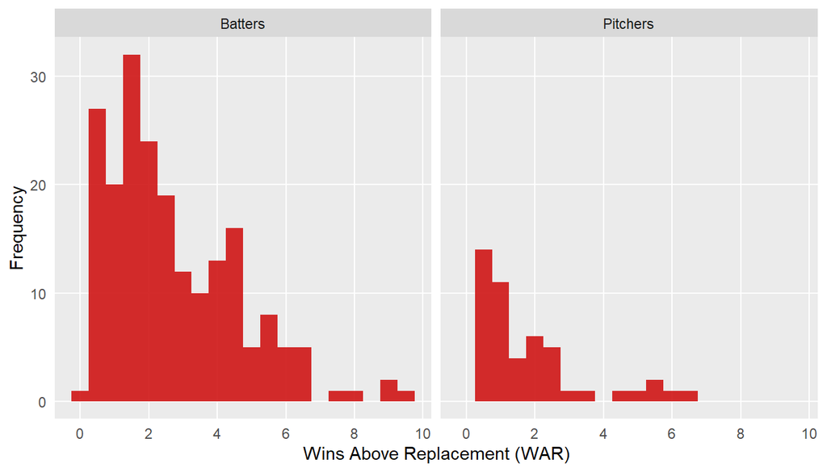

### Final Remarks

On first glance, the relative of pitchers within the top 250 players is concerning. But this might not be too far off from the truth. While there are roughly the same number of pitchers and batters within our player universe, most of pitchers are middle relief pitchers. These players don’t get a ton of winning and rarely earn wins or saves, making them worthless in most fantasy baseball leagues. Pitching performances also tend to be more variable than batting performances. Outside of elite pitchers, it’s pretty common for team owners to sit pitchers in unfavorable pitching matchups. But my valuation systems assumes you are starting a pitchers for all of their matchups. Finally, unlike batter, pitchers don’t really contribute in all categories. Starting pitchers don’t earn saves and closers rarely earn wins. And, because our baseline performance is based on a mix of starting and relief pitchers, starting pitchers are worth negative WAR in the Saves category. Over the course of the season, those negative values add up and explain why pitchers have a lower ceiling than batters.